# Assignment 2

Miguel Perez Luna

9/16/2020

```r
library(tidyverse)
library(ggplot2)
library(scales)
```

I’ll start by loading the person-level data I created in Assignment 1 using read.csv().

```r
person_data <- read.csv("transpo_data.csv")
attach(person_data)
```

These are the variables that I am considering:

1. Sex (SEX) (categorical)
2. Means of Transportation to Work (JWTR) (categorical)
3. Educational Attainment (SCHL) (categorical)
4. Vehicles (1 ton or less) available (vehicle) (continuous)
5. Income (PINCP) (continuous)
6. Travel Time to Work (JWMNP) (continuous)
7. Gross Rent (GRNTP) (continuous)
8. Age (AGEP) (continuous)

I will start by finding the sample mean, sample standard deviation, 95% confidence interval for the population mean, and the interquartile range for my continuous variables. I will also build a histogram for each one to show its distribution.

## Number of Vehicles Available

The summary of the number of vehicles is below.

```r
vehicle_summary <- summary(person_data$vehicle)

vehicle_summary
```

```
##    Min. 1st Qu.  Median    Mean 3rd Qu.    Max.
##   0.000   1.000   2.000   1.926   2.000   6.000
```

The standard deviation of the number of vehicles is below.

```r
sd(person_data$vehicle)
```

```
## [1] 1.055921
```

The 95% confidence interval for the population mean of the number of vehicles is below.

```r
conf_int <- t.test(person_data$vehicle)

conf_int
```

```
##
##  One Sample t-test
##
## data:  person_data$vehicle
## t = 151.64, df = 6913, p-value < 2.2e-16
## alternative hypothesis: true mean is not equal to 0
## 95 percent confidence interval:
##  1.900764 1.950552
## sample estimates:
## mean of x
##  1.925658
```

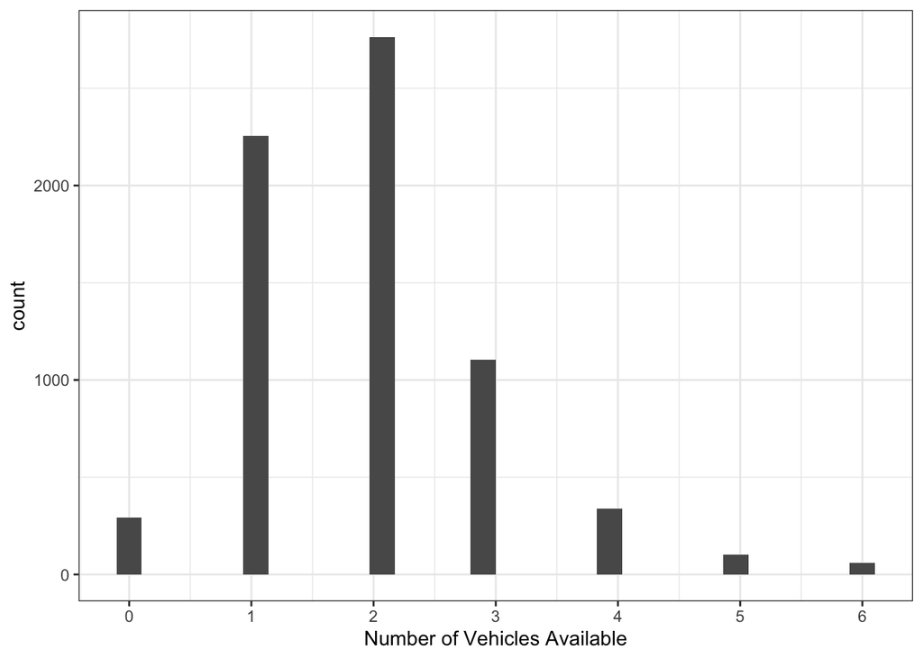

```r
ggplot(person_data,
       aes(x = vehicle)) +
          geom_histogram() +
scale_x_continuous(name = "Number of Vehicles Available",
                  breaks = seq(0, 6, by = 1)) +
theme_bw()
```

```r
pdf('vehicle.pdf')
ggplot(person_data,
       aes(x = vehicle)) +
          geom_histogram() +
scale_x_continuous(name = "Number of Vehicles Available",
                  breaks = seq(0, 6, by = 1)) +
theme_bw()
dev.off()
```

## Income

The summary of the income is below.

```r
PINCP_summary <- summary(person_data$PINCP)

PINCP_summary
```

```
##    Min. 1st Qu.  Median    Mean 3rd Qu.    Max.
##     100   20185   34900   42726   53500  520000
```

The standard deviation of the income is below.

```r
sd(person_data$PINCP)
```

```
## [1] 40789.26
```

The 95% confidence interval for the population mean of the income is below.

```r
conf_int <- t.test(person_data$PINCP)

conf_int
```

```
##
##  One Sample t-test
##
## data:  person_data$PINCP
## t = 87.099, df = 6913, p-value < 2.2e-16
## alternative hypothesis: true mean is not equal to 0
## 95 percent confidence interval:
##  41764.79 43688.04
## sample estimates:
## mean of x
##  42726.42
```

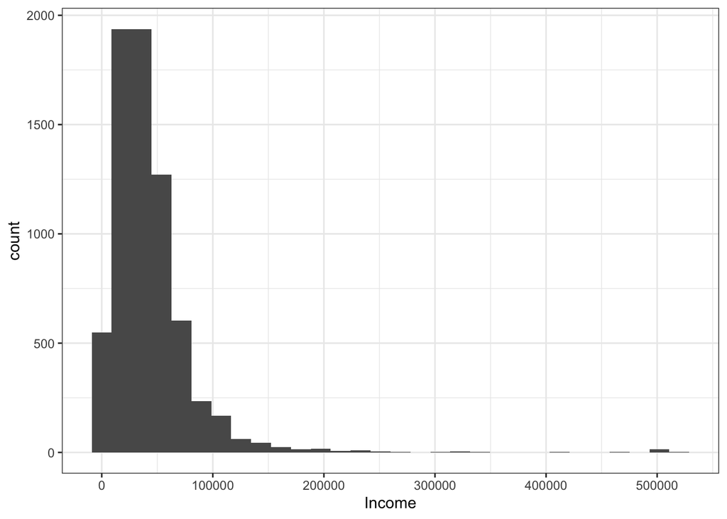

```r
options(scipen = 999)
ggplot(person_data,
       aes(x = PINCP)) +
          geom_histogram() +
scale_x_continuous(name = "Income",
                  breaks = seq(0, 1200000, by = 100000)) +
theme_bw()
```

```r
pdf('income.pdf')
options(scipen = 999)
ggplot(person_data,
       aes(x = PINCP)) +
          geom_histogram() +
scale_x_continuous(name = "Income",
                  breaks = seq(0, 1200000, by = 100000)) +
theme_bw()
dev.off()
```

## Travel Time to Work

The summary of the travel time to work is below.

```r
JWMNP_summary <- summary(person_data$JWMNP)

JWMNP_summary
```

```
##    Min. 1st Qu.  Median    Mean 3rd Qu.    Max.
##    1.00   10.00   20.00   24.79   30.00  157.00
```

The standard deviation of the travel time to work is below.

```r
sd(person_data$JWMNP)
```

```
## [1] 21.88212
```

The 95% confidence interval for the population mean of the travel time to work is below.

```r
conf_int <- t.test(person_data$JWMNP)

conf_int
```

```
##
##  One Sample t-test
##
## data:  person_data$JWMNP
## t = 94.182, df = 6913, p-value < 0.00000000000000022
## alternative hypothesis: true mean is not equal to 0
## 95 percent confidence interval:
##  24.26934 25.30110
## sample estimates:
## mean of x
##  24.78522
```

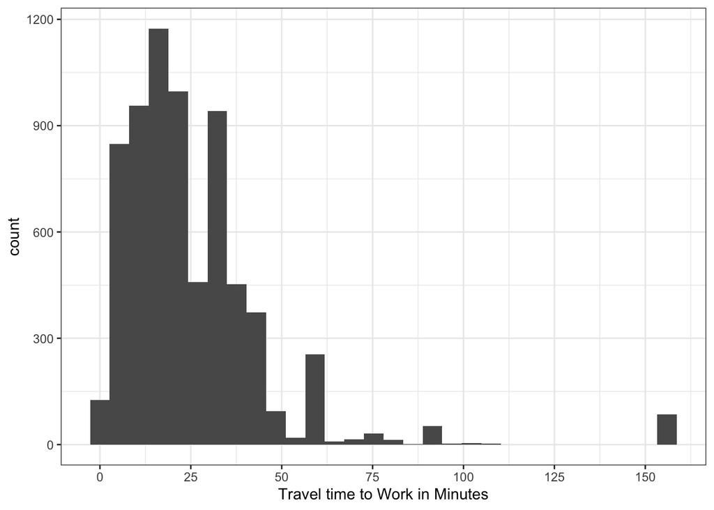

```r
ggplot(person_data,
       aes(x = JWMNP)) +
          geom_histogram() +
scale_x_continuous(name = "Travel time to Work in Minutes",
                  breaks = seq(0, 160, by = 25)) +
theme_bw()
```

```r
pdf('traveltime.pdf')
ggplot(person_data,
       aes(x = JWMNP)) +
          geom_histogram() +
scale_x_continuous(name = "Travel time to Work in Minutes",
                  breaks = seq(0, 160, by = 25)) +
theme_bw()
dev.off()
```

## Gross Rent

The summary of the gross rent is below.

```r
GRNTP_summary <- summary(person_data$GRNTP)

GRNTP_summary
```

```
##    Min. 1st Qu.  Median    Mean 3rd Qu.    Max.
##       8    1047    1405    1466    1801    4190
```

The standard deviation of the gross rent is below.

```r
sd(person_data$GRNTP)
```

```
## [1] 581.2775
```

The 95% confidence interval for the population mean of the gross rent is below.

```r
conf_int <- t.test(person_data$GRNTP)

conf_int
```

```
##
##  One Sample t-test
##
## data:  person_data$GRNTP
## t = 209.72, df = 6913, p-value < 0.00000000000000022
## alternative hypothesis: true mean is not equal to 0
## 95 percent confidence interval:
##  1452.361 1479.769
## sample estimates:
## mean of x
##  1466.065
```

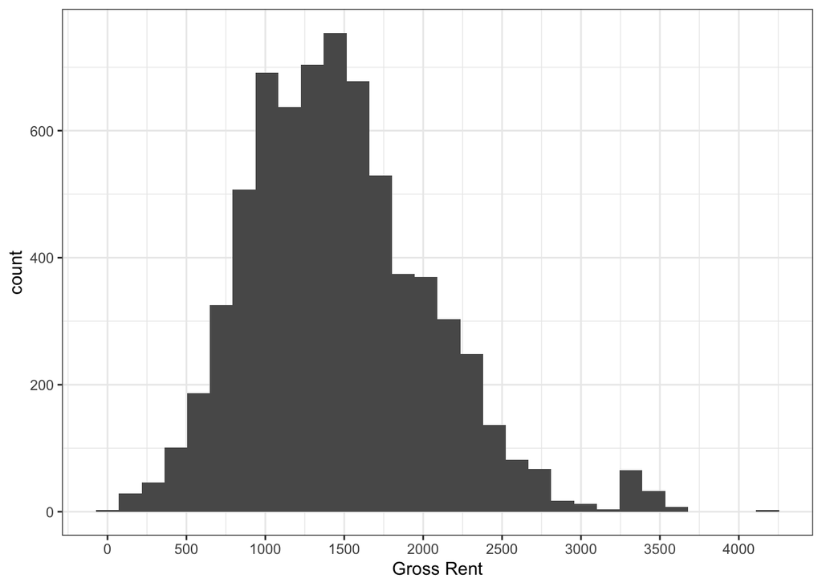

```r
ggplot(person_data,
       aes(x = GRNTP)) +
          geom_histogram() +
scale_x_continuous(name = "Gross Rent",
                  breaks = seq(0, 5000, by = 500)) +
theme_bw()
```

```r
pdf('rent.pdf')
ggplot(person_data,
       aes(x = GRNTP)) +
          geom_histogram() +
scale_x_continuous(name = "Gross Rent",
                  breaks = seq(0, 5000, by = 500)) +
theme_bw()
dev.off()
```

## Age

The summary of the age variable is below.

```r
AGEP_summary <- summary(person_data$AGEP)

AGEP_summary
```

```
##    Min. 1st Qu.  Median    Mean 3rd Qu.    Max.
##    16.0    26.0    32.0    35.9    44.0    93.0
```

The standard deviation of ages is below.

```r
sd(person_data$AGEP)
```

```
## [1] 12.76424
```

The 95% confidence interval for the population mean of ages is below.

```r
conf_int <- t.test(person_data$AGEP)

conf_int
```

```
##
##  One Sample t-test
##
## data:  person_data$AGEP
## t = 233.83, df = 6913, p-value < 0.00000000000000022
## alternative hypothesis: true mean is not equal to 0
## 95 percent confidence interval:
##  35.59407 36.19592
## sample estimates:
## mean of x
##    35.895
```

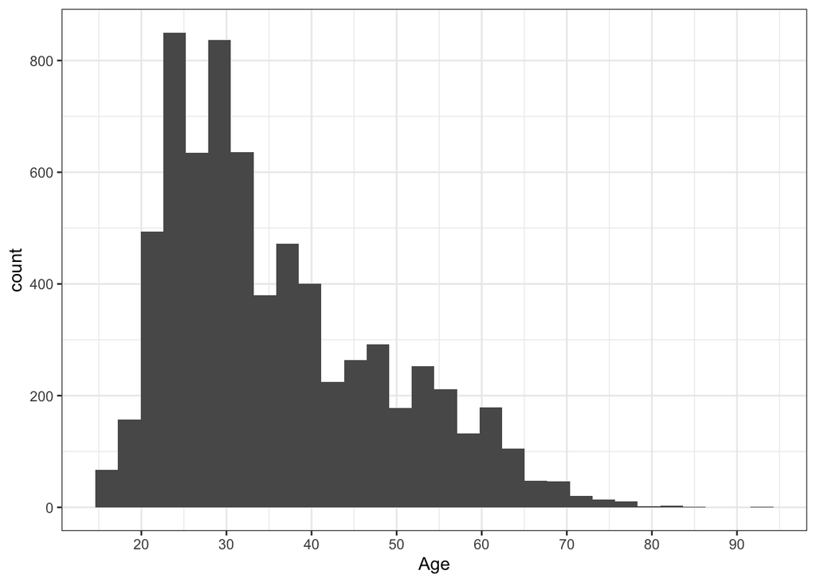

```r
ggplot(person_data,
       aes(x = AGEP)) +
          geom_histogram() +
scale_x_continuous(name = "Age",
                  breaks = seq(0, 90, by = 10)) +
theme_bw()
```

```r
pdf('age.pdf')
ggplot(person_data,
       aes(x = AGEP)) +
          geom_histogram() +
scale_x_continuous(name = "Age",
                  breaks = seq(0, 90, by = 10)) +
theme_bw()
dev.off()
```

## Sex

It looks like there are two possible values of the Sex variable.

```r
unique(person_data$SEX_label)
```

```
## [1] "Male"   "Female"
```

The table below shows the number of observations in each category.

```r
table(person_data$SEX_label)
```

```
##
## Female   Male
##   3173   3741
```

I’ll convert these values to proportions by dividing by the total number of observations.

```r
table(person_data$SEX_label) / sum(table(person_data$SEX_label))
```

```
##
##    Female      Male
## 0.4589239 0.5410761
```

The 95% confidence interval for the proportion of females and males is below.

```r
t.test(person_data$SEX_label == "Female")
```

```
##
##  One Sample t-test
##
## data:  person_data$SEX_label == "Female"
## t = 76.573, df = 6913, p-value < 0.00000000000000022
## alternative hypothesis: true mean is not equal to 0
## 95 percent confidence interval:
##  0.4471752 0.4706726
## sample estimates:
## mean of x
## 0.4589239
```

```r
t.test(person_data$SEX_label == "Male")
```

```
##
##  One Sample t-test
##
## data:  person_data$SEX_label == "Male"
## t = 90.28, df = 6913, p-value < 0.00000000000000022
## alternative hypothesis: true mean is not equal to 0
## 95 percent confidence interval:
##  0.5293274 0.5528248
## sample estimates:
## mean of x
## 0.5410761
```

## Means of Transportation to Work

It looks like there are ten possible values of the means of transportation to work variable.

```r
unique(person_data$JWTR_label)
```

```
##  [1] "Car, truck, or van"
##  [2] "Walked"
##  [3] "Bicycle"
##  [4] "Bus or trolley bus"
##  [5] "Subway or elevated"
##  [6] "Other method"
##  [7] "Taxicab"
##  [8] "Motorcycle"
##  [9] "Railroad"
## [10] "Streetcar or trolley car (carro publico in Puerto Rico)"
```

The table below shows the number of observations in each category.

```r
table(person_data$JWTR_label)
```

```
##
##                                                 Bicycle
##                                                     129
##                                      Bus or trolley bus
##                                                     212
##                                      Car, truck, or van
##                                                    6058
##                                              Motorcycle
##                                                      16
##                                            Other method
##                                                      61
##                                                Railroad
##                                                      32
## Streetcar or trolley car (carro publico in Puerto Rico)
##                                                      10
##                                      Subway or elevated
##                                                      34
##                                                 Taxicab
##                                                      19
##                                                  Walked
##                                                     343
```

I’ll convert these values to proportions by dividing by the total number of observations.

```r
table(person_data$JWTR_label) / sum(table(person_data$JWTR_label))
```

```
##
##                                                 Bicycle
##                                             0.018657796
##                                      Bus or trolley bus
##                                             0.030662424
##                                      Car, truck, or van
##                                             0.876193231
##                                              Motorcycle
##                                             0.002314145
##                                            Other method
##                                             0.008822679
##                                                Railroad
##                                             0.004628290
## Streetcar or trolley car (carro publico in Puerto Rico)
##                                             0.001446341
##                                      Subway or elevated
##                                             0.004917559
##                                                 Taxicab
##                                             0.002748047
##                                                  Walked
##                                             0.049609488
```

The 95% confidence interval for the proportion of each value is below.

```r
t.test(person_data$JWTR_label == "Bicycle")
```

```
##
##  One Sample t-test
##
## data:  person_data$JWTR_label == "Bicycle"
## t = 11.464, df = 6913, p-value < 0.00000000000000022
## alternative hypothesis: true mean is not equal to 0
## 95 percent confidence interval:
##  0.01546750 0.02184809
## sample estimates:
## mean of x
## 0.0186578
```

```r
t.test(person_data$JWTR_label == "Bus or trolley bus ")
```

```
##
##  One Sample t-test
##
## data:  person_data$JWTR_label == "Bus or trolley bus "
## t = NaN, df = 6913, p-value = NA
## alternative hypothesis: true mean is not equal to 0
## 95 percent confidence interval:
##  NaN NaN
## sample estimates:
## mean of x
##         0
```

```r
t.test(person_data$JWTR_label == "Car, truck, or van")
```

```
##
##  One Sample t-test
##
## data:  person_data$JWTR_label == "Car, truck, or van"
## t = 221.19, df = 6913, p-value < 0.00000000000000022
## alternative hypothesis: true mean is not equal to 0
## 95 percent confidence interval:
##  0.8684278 0.8839586
## sample estimates:
## mean of x
## 0.8761932
```

```r
t.test(person_data$JWTR_label == "Motorcycle")
```

```
##
##  One Sample t-test
##
## data:  person_data$JWTR_label == "Motorcycle"
## t = 4.0043, df = 6913, p-value = 0.00006284
## alternative hypothesis: true mean is not equal to 0
## 95 percent confidence interval:
##  0.001181267 0.003447023
## sample estimates:
##   mean of x
## 0.002314145
```

```r
t.test(person_data$JWTR_label == "Other method")
```

```
##
##  One Sample t-test
##
## data:  person_data$JWTR_label == "Other method"
## t = 7.8444, df = 6913, p-value = 0.000000000000005008
## alternative hypothesis: true mean is not equal to 0
## 95 percent confidence interval:
##  0.006617891 0.011027466
## sample estimates:
##   mean of x
## 0.008822679
```

```r
t.test(person_data$JWTR_label == "Railroad")
```

```
##
##  One Sample t-test
##
## data:  person_data$JWTR_label == "Railroad"
## t = 5.6696, df = 6913, p-value = 0.00000001489
## alternative hypothesis: true mean is not equal to 0
## 95 percent confidence interval:
##  0.003028018 0.006228562
## sample estimates:
##  mean of x
## 0.00462829
```

```r
t.test(person_data$JWTR_label == "Streetcar or trolley car (carro publico in Puerto Rico)")
```

```
##
##  One Sample t-test
##
## data:  person_data$JWTR_label == "Streetcar or trolley car (carro publico in Puerto Rico)"
## t = 3.1643, df = 6913, p-value = 0.001561
## alternative hypothesis: true mean is not equal to 0
## 95 percent confidence interval:
##  0.0005503328 0.0023423487
## sample estimates:
##   mean of x
## 0.001446341
```

```r
t.test(person_data$JWTR_label == "Subway or elevated")
```

```
##
##  One Sample t-test
##
## data:  person_data$JWTR_label == "Subway or elevated"
## t = 5.8449, df = 6913, p-value = 0.000000005299
## alternative hypothesis: true mean is not equal to 0
## 95 percent confidence interval:
##  0.003268276 0.006566841
## sample estimates:
##   mean of x
## 0.004917559
```

```r
t.test(person_data$JWTR_label == "Taxicab")
```

```
##
##  One Sample t-test
##
## data:  person_data$JWTR_label == "Taxicab"
## t = 4.3646, df = 6913, p-value = 0.00001292
## alternative hypothesis: true mean is not equal to 0
## 95 percent confidence interval:
##  0.001513791 0.003982304
## sample estimates:
##   mean of x
## 0.002748047
```

```r
t.test(person_data$JWTR_label == "Walked")
```

```
##
##  One Sample t-test
##
## data:  person_data$JWTR_label == "Walked"
## t = 18.996, df = 6913, p-value < 0.00000000000000022
## alternative hypothesis: true mean is not equal to 0
## 95 percent confidence interval:
##  0.04449003 0.05472895
## sample estimates:
##  mean of x
## 0.04960949
```

## Educational Attainment

```r
unique(person_data$SCHL_label)
```

```
##  [1] "Some college, but less than 1 year"
##  [2] "Regular high school diploma"
##  [3] "Bachelor's degree"
##  [4] "1 or more years of college credit, no degree"
##  [5] "Master's degree"
##  [6] "GED or alternative credential"
##  [7] "Doctorate degree"
##  [8] "Associate's degree"
##  [9] "Grade 8"
## [10] "Grade 7"
## [11] "Grade 10"
## [12] "12th grade - no diploma"
## [13] "Grade 6"
## [14] "Grade 11"
## [15] "Professional degree beyond a bachelor's degree"
## [16] "Grade 9"
## [17] "No schooling completed"
## [18] "Grade 5"
## [19] "Grade 4"
## [20] "Nursery school, preschool"
## [21] "Grade 3"
## [22] "Grade 1"
## [23] "Kindergarten"
## [24] "Grade 2"
```

The table below shows the number of observations in each category.

```r
table(person_data$SCHL_label)
```

```
##
##   1 or more years of college credit, no degree
##                                           1167
##                        12th grade - no diploma
##                                            112
##                             Associate's degree
##                                            607
##                              Bachelor's degree
##                                           1834
##                               Doctorate degree
##                                             98
##                  GED or alternative credential
##                                            308
##                                        Grade 1
##                                              2
##                                       Grade 10
##                                             91
##                                       Grade 11
##                                            150
##                                        Grade 2
##                                              2
##                                        Grade 3
##                                              3
##                                        Grade 4
##                                              3
##                                        Grade 5
##                                              6
##                                        Grade 6
##                                             52
##                                        Grade 7
##                                             15
##                                        Grade 8
##                                             24
##                                        Grade 9
##                                             56
##                                   Kindergarten
##                                              2
##                                Master's degree
##                                            573
##                         No schooling completed
##                                             50
##                      Nursery school, preschool
##                                              1
## Professional degree beyond a bachelor's degree
##                                            108
##                    Regular high school diploma
##                                           1180
##             Some college, but less than 1 year
##                                            470
```

I’ll convert these values to proportions by dividing by the total number of observations.

```r
table(person_data$SCHL_label) / sum(table(person_data$SCHL_label))
```

```
##
##   1 or more years of college credit, no degree
##                                   0.1687879664
##                        12th grade - no diploma
##                                   0.0161990165
##                             Associate's degree
##                                   0.0877928840
##                              Bachelor's degree
##                                   0.2652588950
##                               Doctorate degree
##                                   0.0141741394
##                  GED or alternative credential
##                                   0.0445472953
##                                        Grade 1
##                                   0.0002892682
##                                       Grade 10
##                                   0.0131617009
##                                       Grade 11
##                                   0.0216951114
##                                        Grade 2
##                                   0.0002892682
##                                        Grade 3
##                                   0.0004339022
##                                        Grade 4
##                                   0.0004339022
##                                        Grade 5
##                                   0.0008678045
##                                        Grade 6
##                                   0.0075209719
##                                        Grade 7
##                                   0.0021695111
##                                        Grade 8
##                                   0.0034712178
##                                        Grade 9
##                                   0.0080995082
##                                   Kindergarten
##                                   0.0002892682
##                                Master's degree
##                                   0.0828753254
##                         No schooling completed
##                                   0.0072317038
##                      Nursery school, preschool
##                                   0.0001446341
## Professional degree beyond a bachelor's degree
##                                   0.0156204802
##                    Regular high school diploma
##                                   0.1706682094
##             Some college, but less than 1 year
##                                   0.0679780156
```

The 95% confidence interval for the proportion of each value is below.

```r
t.test(person_data$SCHL_label == "No schooling completed")
```

```
##
##  One Sample t-test
##
## data:  person_data$SCHL_label == "No schooling completed"
## t = 7.0963, df = 6913, p-value = 0.000000000001409
## alternative hypothesis: true mean is not equal to 0
## 95 percent confidence interval:
##  0.005233981 0.009229426
## sample estimates:
##   mean of x
## 0.007231704
```

```r
t.test(person_data$SCHL_label == "Kindergarten")
```

```
##
##  One Sample t-test
##
## data:  person_data$SCHL_label == "Kindergarten"
## t = 1.4143, df = 6913, p-value = 0.1573
## alternative hypothesis: true mean is not equal to 0
## 95 percent confidence interval:
##  -0.0001116709  0.0006902072
## sample estimates:
##    mean of x
## 0.0002892682
```

```r
t.test(person_data$SCHL_label == "Grade 1")
```

```
##
##  One Sample t-test
##
## data:  person_data$SCHL_label == "Grade 1"
## t = 1.4143, df = 6913, p-value = 0.1573
## alternative hypothesis: true mean is not equal to 0
## 95 percent confidence interval:
##  -0.0001116709  0.0006902072
## sample estimates:
##    mean of x
## 0.0002892682
```

```r
t.test(person_data$SCHL_label == "Grade 2")
```

```
##
##  One Sample t-test
##
## data:  person_data$SCHL_label == "Grade 2"
## t = 1.4143, df = 6913, p-value = 0.1573
## alternative hypothesis: true mean is not equal to 0
## 95 percent confidence interval:
##  -0.0001116709  0.0006902072
## sample estimates:
##    mean of x
## 0.0002892682
```

```r
t.test(person_data$SCHL_label == "Grade 3")
```

```
##
##  One Sample t-test
##
## data:  person_data$SCHL_label == "Grade 3"
## t = 1.7323, df = 6913, p-value = 0.08326
## alternative hypothesis: true mean is not equal to 0
## 95 percent confidence interval:
##  -0.00005711028  0.00092491474
## sample estimates:
##    mean of x
## 0.0004339022
```

```r
t.test(person_data$SCHL_label == "Grade 4")
```

```
##
##  One Sample t-test
##
## data:  person_data$SCHL_label == "Grade 4"
## t = 1.7323, df = 6913, p-value = 0.08326
## alternative hypothesis: true mean is not equal to 0
## 95 percent confidence interval:
##  -0.00005711028  0.00092491474
## sample estimates:
##    mean of x
## 0.0004339022
```

```r
t.test(person_data$SCHL_label == "Grade 5")
```

```
##
##  One Sample t-test
##
## data:  person_data$SCHL_label == "Grade 5"
## t = 2.4504, df = 6913, p-value = 0.0143
## alternative hypothesis: true mean is not equal to 0
## 95 percent confidence interval:
##  0.0001735586 0.0015620503
## sample estimates:
##    mean of x
## 0.0008678045
```

```r
t.test(person_data$SCHL_label == "Grade 6")
```

```
##
##  One Sample t-test
##
## data:  person_data$SCHL_label == "Grade 6"
## t = 7.2379, df = 6913, p-value = 0.0000000000005051
## alternative hypothesis: true mean is not equal to 0
## 95 percent confidence interval:
##  0.005483984 0.009557960
## sample estimates:
##   mean of x
## 0.007520972
```

```r
t.test(person_data$SCHL_label == "Grade 7")
```

```
##
##  One Sample t-test
##
## data:  person_data$SCHL_label == "Grade 7"
## t = 3.8769, df = 6913, p-value = 0.0001068
## alternative hypothesis: true mean is not equal to 0
## 95 percent confidence interval:
##  0.001072527 0.003266495
## sample estimates:
##   mean of x
## 0.002169511
```

```r
t.test(person_data$SCHL_label == "Grade 8")
```

```
##
##  One Sample t-test
##
## data:  person_data$SCHL_label == "Grade 8"
## t = 4.9071, df = 6913, p-value = 0.0000009452
## alternative hypothesis: true mean is not equal to 0
## 95 percent confidence interval:
##  0.002084536 0.004857899
## sample estimates:
##   mean of x
## 0.003471218
```

```r
t.test(person_data$SCHL_label == "Grade 9")
```

```
##
##  One Sample t-test
##
## data:  person_data$SCHL_label == "Grade 9"
## t = 7.5133, df = 6913, p-value = 0.00000000000006494
## alternative hypothesis: true mean is not equal to 0
## 95 percent confidence interval:
##  0.005986242 0.010212775
## sample estimates:
##   mean of x
## 0.008099508
```

```r
t.test(person_data$SCHL_label == "Grade 10")
```

```
##
##  One Sample t-test
##
## data:  person_data$SCHL_label == "Grade 10"
## t = 9.6021, df = 6913, p-value < 0.00000000000000022
## alternative hypothesis: true mean is not equal to 0
## 95 percent confidence interval:
##  0.01047469 0.01584871
## sample estimates:
## mean of x
## 0.0131617
```

```r
t.test(person_data$SCHL_label == "Grade 11")
```

```
##
##  One Sample t-test
##
## data:  person_data$SCHL_label == "Grade 11"
## t = 12.382, df = 6913, p-value < 0.00000000000000022
## alternative hypothesis: true mean is not equal to 0
## 95 percent confidence interval:
##  0.01826025 0.02512997
## sample estimates:
##  mean of x
## 0.02169511
```

```r
t.test(person_data$SCHL_label == "12th grade - no diploma")
```

```
##
##  One Sample t-test
##
## data:  person_data$SCHL_label == "12th grade - no diploma"
## t = 10.669, df = 6913, p-value < 0.00000000000000022
## alternative hypothesis: true mean is not equal to 0
## 95 percent confidence interval:
##  0.01322263 0.01917540
## sample estimates:
##  mean of x
## 0.01619902
```

```r
t.test(person_data$SCHL_label == "Regular high school diploma")
```

```
##
##  One Sample t-test
##
## data:  person_data$SCHL_label == "Regular high school diploma"
## t = 37.718, df = 6913, p-value < 0.00000000000000022
## alternative hypothesis: true mean is not equal to 0
## 95 percent confidence interval:
##  0.1617981 0.1795384
## sample estimates:
## mean of x
## 0.1706682
```

```r
t.test(person_data$SCHL_label == "GED or alternative credential")
```

```
##
##  One Sample t-test
##
## data:  person_data$SCHL_label == "GED or alternative credential"
## t = 17.953, df = 6913, p-value < 0.00000000000000022
## alternative hypothesis: true mean is not equal to 0
## 95 percent confidence interval:
##  0.03968315 0.04941144
## sample estimates:
## mean of x
## 0.0445473
```

```r
t.test(person_data$SCHL_label == "Some college, but less than 1 year")
```

```
##
##  One Sample t-test
##
## data:  person_data$SCHL_label == "Some college, but less than 1 year"
## t = 22.455, df = 6913, p-value < 0.00000000000000022
## alternative hypothesis: true mean is not equal to 0
## 95 percent confidence interval:
##  0.06204346 0.07391257
## sample estimates:
##  mean of x
## 0.06797802
```

```r
t.test(person_data$SCHL_label == "1 or more years of college credit, no degree")
```

```
##
##  One Sample t-test
##
## data:  person_data$SCHL_label == "1 or more years of college credit, no degree"
## t = 37.467, df = 6913, p-value < 0.00000000000000022
## alternative hypothesis: true mean is not equal to 0
## 95 percent confidence interval:
##  0.1599568 0.1776191
## sample estimates:
## mean of x
##  0.168788
```

```r
t.test(person_data$SCHL_label == "Associate's degree")
```

```
##
##  One Sample t-test
##
## data:  person_data$SCHL_label == "Associate's degree"
## t = 25.794, df = 6913, p-value < 0.00000000000000022
## alternative hypothesis: true mean is not equal to 0
## 95 percent confidence interval:
##  0.08112071 0.09446506
## sample estimates:
##  mean of x
## 0.08779288
```

```r
t.test(person_data$SCHL_label == "Bachelor's degree")
```

```
##
##  One Sample t-test
##
## data:  person_data$SCHL_label == "Bachelor's degree"
## t = 49.958, df = 6913, p-value < 0.00000000000000022
## alternative hypothesis: true mean is not equal to 0
## 95 percent confidence interval:
##  0.2548503 0.2756675
## sample estimates:
## mean of x
## 0.2652589
```

```r
t.test(person_data$SCHL_label == "Professional degree beyond a bachelor's degree")
```

```
##
##  One Sample t-test
##
## data:  person_data$SCHL_label == "Professional degree beyond a bachelor's degree"
## t = 10.474, df = 6913, p-value < 0.00000000000000022
## alternative hypothesis: true mean is not equal to 0
## 95 percent confidence interval:
##  0.01269687 0.01854409
## sample estimates:
##  mean of x
## 0.01562048
```

```r
t.test(person_data$SCHL_label == "Master's degree")
```

```
##
##  One Sample t-test
##
## data:  person_data$SCHL_label == "Master's degree"
## t = 24.994, df = 6913, p-value < 0.00000000000000022
## alternative hypothesis: true mean is not equal to 0
## 95 percent confidence interval:
##  0.07637526 0.08937539
## sample estimates:
##  mean of x
## 0.08287533
```

```r
t.test(person_data$SCHL_label == "Doctorate degree")
```

```
##
##  One Sample t-test
##
## data:  person_data$SCHL_label == "Doctorate degree"
## t = 9.9697, df = 6913, p-value < 0.00000000000000022
## alternative hypothesis: true mean is not equal to 0
## 95 percent confidence interval:
##  0.01138712 0.01696115
## sample estimates:
##  mean of x
## 0.01417414
```

## Formatting

Below I will try and format the information for each of my categorical variables above.

### Sex

```r
sex <- unique(SEX_label)
sex
```

```
## [1] "Male"   "Female"
```

```r
male <- t.test(SEX_label == sex[1])
female <- t.test(SEX_label == sex[2])

shares <- tibble('Sex' = c("Male",
                        "Female"),
                 `Share` = c(male$estimate,
                            female$estimate),
                 Low = c(male$conf.int[1],
                         female$conf.int[1]),
                 High = c(male$conf.int[2],
                         female$conf.int[2]))
knitr::kable(shares, caption = "Proportions and 95-percent confidence intervals")
```

Proportions and 95-percent confidence intervals

| Sex | Share | Low | High |
| --- | --- | --- | --- |
| Male | 0.5410761 | 0.5293274 | 0.5528248 |
| Female | 0.4589239 | 0.4471752 | 0.4706726 |

### Means of transportation to work

```r
meansoftravel <- unique(JWTR_label)
meansoftravel
```

```
##  [1] "Car, truck, or van"
##  [2] "Walked"
##  [3] "Bicycle"
##  [4] "Bus or trolley bus"
##  [5] "Subway or elevated"
##  [6] "Other method"
##  [7] "Taxicab"
##  [8] "Motorcycle"
##  [9] "Railroad"
## [10] "Streetcar or trolley car (carro publico in Puerto Rico)"
```

```r
car_truck_van <- t.test(JWTR_label == meansoftravel[1])
walked <- t.test(JWTR_label == meansoftravel[2])
bicycle <-  t.test(JWTR_label == meansoftravel[3])
bus_trolleybus <- t.test(JWTR_label == meansoftravel[4])
subway_elevated <- t.test(JWTR_label == meansoftravel[5])
other <- t.test(JWTR_label == meansoftravel[6])
taxicab <- t.test(JWTR_label == meansoftravel[7])
motorcycle <- t.test(JWTR_label == meansoftravel[8])
railroad <- t.test(JWTR_label == meansoftravel[9])
streetcar_trolley <-  t.test(JWTR_label == meansoftravel[10])

shares <- tibble('Means of Travel' = c("Car, Truck, or Van",
                            "Walked",
                            "Bicycle",
                            "Bus or Trolley Bus",
                            "Subway or Elevated",
                            "Other Method",
                            "Taxicab",
                            "Motorcycle",
                            "Railroad",
                            "Streetcar or Trolley Car"),
                 `Share` = c(car_truck_van$estimate,
                             walked$estimate,
                             bicycle$estimate,
                             bus_trolleybus$estimate,
                             subway_elevated$estimate,
                             other$estimate,
                             taxicab$estimate,
                             motorcycle$estimate,
                             railroad$estimate,
                             streetcar_trolley$estimate),
                 Low = c(car_truck_van$conf.int[1],
                             walked$conf.int[1],
                             bicycle$conf.int[1],
                             bus_trolleybus$conf.int[1],
                             subway_elevated$conf.int[1],
                             other$conf.int[1],
                             taxicab$conf.int[1],
                             motorcycle$conf.int[1],
                             railroad$conf.int[1],
                             streetcar_trolley$conf.int[1]),
                 High = c(car_truck_van$conf.int[2],
                             walked$conf.int[2],
                             bicycle$conf.int[2],
                             bus_trolleybus$conf.int[2],
                             subway_elevated$conf.int[2],
                             other$conf.int[2],
                             taxicab$conf.int[2],
                             motorcycle$conf.int[2],
                             railroad$conf.int[2],
                             streetcar_trolley$conf.int[2]))
knitr::kable(shares, caption = "Proportions and 95-percent confidence intervals")
```

Proportions and 95-percent confidence intervals

| Means of Travel | Share | Low | High |
| --- | --- | --- | --- |
| Car, Truck, or Van | 0.8761932 | 0.8684278 | 0.8839586 |
| Walked | 0.0496095 | 0.0444900 | 0.0547289 |
| Bicycle | 0.0186578 | 0.0154675 | 0.0218481 |
| Bus or Trolley Bus | 0.0306624 | 0.0265977 | 0.0347272 |
| Subway or Elevated | 0.0049176 | 0.0032683 | 0.0065668 |
| Other Method | 0.0088227 | 0.0066179 | 0.0110275 |
| Taxicab | 0.0027480 | 0.0015138 | 0.0039823 |
| Motorcycle | 0.0023141 | 0.0011813 | 0.0034470 |
| Railroad | 0.0046283 | 0.0030280 | 0.0062286 |
| Streetcar or Trolley Car | 0.0014463 | 0.0005503 | 0.0023423 |

### Educational Attainmnet

```r
education <- unique(SCHL_label)
education
```

```
##  [1] "Some college, but less than 1 year"
##  [2] "Regular high school diploma"
##  [3] "Bachelor's degree"
##  [4] "1 or more years of college credit, no degree"
##  [5] "Master's degree"
##  [6] "GED or alternative credential"
##  [7] "Doctorate degree"
##  [8] "Associate's degree"
##  [9] "Grade 8"
## [10] "Grade 7"
## [11] "Grade 10"
## [12] "12th grade - no diploma"
## [13] "Grade 6"
## [14] "Grade 11"
## [15] "Professional degree beyond a bachelor's degree"
## [16] "Grade 9"
## [17] "No schooling completed"
## [18] "Grade 5"
## [19] "Grade 4"
## [20] "Nursery school, preschool"
## [21] "Grade 3"
## [22] "Grade 1"
## [23] "Kindergarten"
## [24] "Grade 2"
```

```r
lessoneyearcollege <- t.test(SCHL_label == education[1])
highschooldiploma <- t.test(SCHL_label == education[2])
bachelors <- t.test(SCHL_label == education[3])
oneyearcollege <- t.test(SCHL_label == education[4])
masters <- t.test(SCHL_label == education[5])
ged_alternative <- t.test(SCHL_label == education[6])
doctorate <- t.test(SCHL_label == education[7])
associates <- t.test(SCHL_label == education[8])
grade8 <- t.test(SCHL_label == education[9])
grade7 <- t.test(SCHL_label == education[10])
grade10 <- t.test(SCHL_label == education[11])
grade12_nodiploma <- t.test(SCHL_label == education[12])
grade6 <- t.test(SCHL_label == education[13])
grade11 <- t.test(SCHL_label == education[14])
professionaldegree <- t.test(SCHL_label == education[15])
grade9 <- t.test(SCHL_label == education[16])
noschool <- t.test(SCHL_label == education[17])
grade5 <- t.test(SCHL_label == education[18])
grade4 <- t.test(SCHL_label == education[19])
nursery_preschool <- t.test(SCHL_label == education[20])
grade_3 <- t.test(SCHL_label == education[21])
grade_1 <- t.test(SCHL_label == education[22])
kindergarten <- t.test(SCHL_label == education[23])
grade_2 <- t.test(SCHL_label == education[24])

shares <- tibble('Educational Attainment' =
                         c("Some college, but less than 1 year",
                            "Regular high school diploma",
                            "Bachelor's Degree",
                            "One year of college, no degree",
                            "Master's Degree",
                            "GED or alternative credential",
                            "Doctorate Degree",
                            "Associate's Degree",
                            "Grade 8",
                            "Grade 7",
                            "Grade 10",
                            "Grade 12 - no diploma",
                            "Grade 6",
                            "Grade 11",
                            "Professional Degree beyond Bachelor's",
                            "Grade 9",
                            "No schooling completed",
                            "Grade 5",
                            "Grade 4",
                            "Nursery schoolor preschool",
                            "Grade 3",
                            "Grade 1",
                            "Kindergarten",
                            "Grade 2"),
                 `Share` = c(lessoneyearcollege$estimate,
                             highschooldiploma$estimate,
                             bachelors$estimate,
                             oneyearcollege$estimate,
                             masters$estimate,
                             ged_alternative$estimate,
                             doctorate$estimate,
                             associates$estimate,
                             grade8$estimate,
                             grade7$estimate,
                             grade10$estimate,
                             grade12_nodiploma$estimate,
                             grade6$estimate,
                             grade11$estimate,
                             professionaldegree$estimate,
                             grade9$estimate,
                             noschool$estimate,
                             grade5$estimate,
                             grade4$estimate,
                             nursery_preschool$estimate,
                             grade_3$estimate,
                             grade_1$estimate,
                             kindergarten$estimate,
                             grade_2$estimate),
                 Low = c(lessoneyearcollege$conf.int[1],
                             highschooldiploma$conf.int[1],
                             bachelors$conf.int[1],
                             oneyearcollege$conf.int[1],
                             masters$conf.int[1],
                             ged_alternative$conf.int[1],
                             doctorate$conf.int[1],
                             associates$conf.int[1],
                             grade8$conf.int[1],
                             grade7$conf.int[1],
                             grade10$conf.int[1],
                             grade12_nodiploma$conf.int[1],
                             grade6$conf.int[1],
                             grade11$conf.int[1],
                             professionaldegree$conf.int[1],
                             grade9$conf.int[1],
                             noschool$conf.int[1],
                             grade5$conf.int[1],
                             grade4$conf.int[1],
                             nursery_preschool$conf.int[1],
                             grade_3$conf.int[1],
                             grade_1$conf.int[1],
                             kindergarten$conf.int[1],
                             grade_2$conf.int[1]),
                 High = c(lessoneyearcollege$conf.int[2],
                             highschooldiploma$conf.int[2],
                             bachelors$conf.int[2],
                             oneyearcollege$conf.int[2],
                             masters$conf.int[2],
                             ged_alternative$conf.int[2],
                             doctorate$conf.int[2],
                             associates$conf.int[2],
                             grade8$conf.int[2],
                             grade7$conf.int[2],
                             grade10$conf.int[2],
                             grade12_nodiploma$conf.int[2],
                             grade6$conf.int[2],
                             grade11$conf.int[2],
                             professionaldegree$conf.int[2],
                             grade9$conf.int[2],
                             noschool$conf.int[2],
                             grade5$conf.int[2],
                             grade4$conf.int[2],
                             nursery_preschool$conf.int[2],
                             grade_3$conf.int[2],
                             grade_1$conf.int[2],
                             kindergarten$conf.int[2],
                             grade_2$conf.int[2]))
knitr::kable(shares, caption = "Proportions and 95-percent confidence intervals")
```

Proportions and 95-percent confidence intervals

| Educational Attainment | Share | Low | High |
| --- | --- | --- | --- |
| Some college, but less than 1 year | 0.0679780 | 0.0620435 | 0.0739126 |
| Regular high school diploma | 0.1706682 | 0.1617981 | 0.1795384 |
| Bachelor’s Degree | 0.2652589 | 0.2548503 | 0.2756675 |
| One year of college, no degree | 0.1687880 | 0.1599568 | 0.1776191 |
| Master’s Degree | 0.0828753 | 0.0763753 | 0.0893754 |
| GED or alternative credential | 0.0445473 | 0.0396832 | 0.0494114 |
| Doctorate Degree | 0.0141741 | 0.0113871 | 0.0169612 |
| Associate’s Degree | 0.0877929 | 0.0811207 | 0.0944651 |
| Grade 8 | 0.0034712 | 0.0020845 | 0.0048579 |
| Grade 7 | 0.0021695 | 0.0010725 | 0.0032665 |
| Grade 10 | 0.0131617 | 0.0104747 | 0.0158487 |
| Grade 12 - no diploma | 0.0161990 | 0.0132226 | 0.0191754 |
| Grade 6 | 0.0075210 | 0.0054840 | 0.0095580 |
| Grade 11 | 0.0216951 | 0.0182603 | 0.0251300 |
| Professional Degree beyond Bachelor’s | 0.0156205 | 0.0126969 | 0.0185441 |
| Grade 9 | 0.0080995 | 0.0059862 | 0.0102128 |
| No schooling completed | 0.0072317 | 0.0052340 | 0.0092294 |
| Grade 5 | 0.0008678 | 0.0001736 | 0.0015621 |
| Grade 4 | 0.0004339 | -0.0000571 | 0.0009249 |
| Nursery schoolor preschool | 0.0001446 | -0.0001389 | 0.0004282 |
| Grade 3 | 0.0004339 | -0.0000571 | 0.0009249 |
| Grade 1 | 0.0002893 | -0.0001117 | 0.0006902 |
| Kindergarten | 0.0002893 | -0.0001117 | 0.0006902 |
| Grade 2 | 0.0002893 | -0.0001117 | 0.0006902 |